# Dashboard Design

```r
library(tidyverse)
library(vroom)
library(sf)
library(tigris)
library(tmap)
pkgload::load_all()

options(tigris_use_cache = TRUE)

covid_datasets <- get_data()
```

# Plan for dashboards

The plan for the application will allow users see information at a high level, and then be able to drill down at the hospital level for detailed information.

- National Summary
  - Needs proper formatting and organization for info boxes
  - Currently first tab has absolute and % change going back 7 days. This information can be pulled directly from HHS, but additional calculations from raw data needs to be performed if the user wants to view these changes further back in time (e.g. yesterday, a week, 30 days, 90 days)
  - Consider identifying number of hospitals not reporting staffing shortages for the map
  - Add per 100k metrics to compare data between states
- Historical trends
  - Consider using ggplotly to add interactivity to charts
- State/County Drilldown
  - Show summary
  - Include hospital locations as well? or show this in different tabs
  - Will also contain a table to include data for hospitals without locations
  - Will need to fix leaflet maps for dropdowns overlaying graphs
- Hospital Profiles
  - Create a summary page to show how hospitals are doing in the pandemic
  - Descriptive Statistics for cases and deaths (used for info boxes)
    - Cumulative
    - Change from last 7 days
    - Percent change from last 7 days
  - Examples of above statistics
    - Hospital admissions (suspected and confirmed)
    - Cases
    - Deaths
    - Viral (RT-PCR) Lab Test Positivity
- Vaccinations
  - Possible create a time series to identify vaccinations?
- About
  - Shows users how the app is organized/how to use it
  - Detail sources used for the application
  - Disclaimer for data not including some hospitals

# National Level Charts

HHS produces a community profile through core based statistical areas CBSA . Take a look at the [National Community Profile Report](https://healthdata.gov/Health/COVID-19-Community-Profile-Report/gqxm-d9w9). There are also reports at the state level, for example, [here is one for New Hampshire](https://docs.google.com/viewerng/viewer?url=https://healthdata.gov/api/views/62ta-rvvi/files/dfc0ee76-e514-42b5-85f3-403699b43fd3)

Some of the calculations provided for these reports can be found online. The table below details the latest information that can be found.

```r
# Load data
cpr_national <- covid_datasets$cpr_national

latest_cases_deaths <- covid_datasets$cases_and_deaths_state_timeseries %>%
  mutate(submission_date = lubridate::mdy(submission_date)) %>%
  filter(submission_date >= max(submission_date) - lubridate::days(7))

# Combine stats
national_summary_stats <- cpr_national %>%
  mutate(
    tot_cases = latest_cases_deaths %>%
      filter(submission_date == max(submission_date)) %>%
      pull(tot_cases) %>%
      sum(),
    tot_death = latest_cases_deaths %>%
      filter(submission_date == max(submission_date)) %>%
      pull(tot_death) %>%
      sum()
  ) %>%
  pivot_longer(everything())

# Print to table
national_summary_stats %>%
  gt::gt()
```

| name | value |
| --- | --- |
| cases_last_7_days | 467229.000 |
| cases_per_100k_last_7_days | 9483.486 |
| cases_pct_change_from_previous_week | -0.026 |
| test_positivity_rate | 0.060 |
| test_positivity_rate_pct_change_from_prev_week | 0.005 |
| confirmed_covid_hosp_last_7_days | 37393.000 |
| confirmed_covid_hosp_per_100k_last_7_days | 10.886 |
| confirmed_covid_hosp_pct_change_from_prev_week | -0.065 |
| deaths_last_7_days | 4847.000 |
| deaths_per_100k_last_7_days | 169.973 |
| deaths_pct_change_from_prev_week | 0.028 |
| tot_cases | 31484148.000 |
| tot_death | 564292.000 |

All sources do not have dates updated at the same time, although they should not be more than one day apart. The update date for the Community Profile Report can be found on the source page, although some Javascript may be needed to pull this information. Below is the date for the latest infomration on cases and deaths by state.

```r
# Updated date
latest_cases_deaths %>%
  pull(submission_date) %>%
  max() %>%
  unique()
```

```
## [1] "2021-04-18"
```

```r
# DOES NOT RUN
# Attempt to get updated dates for time series since they can be slightly different
# test <- read_html("https://healthdata.gov/dataset/COVID-19-Community-Profile-Report-National-Level/gzn6-r8g2")
#
# test %>%
#   html_elements(".date") %>%
#   html_text()
```

# County level metrics

There is also CPR detailing information at the county level. These can can important when developing interactive maps. This should be detailed when querying state or county level information.

```r
cpr_county <- covid_datasets$cpr_county
```

# Facility level metrics

The above metrics come from facility level data.

```r
df <- covid_datasets$reported_patient_impact_hospital_capacity_facility %>%
  select(hospital_pk:is_metro_micro, inpatient_beds_7_day_sum,
         ends_with("avg"), starts_with("previous"),
         geocoded_hospital_address)
```

```r
impute_999999_values <- function(df, formule) {
  df[rlang::as_function(formule)(df)] <- 0
  df
}

df <- df %>%
  impute_999999_values(~ .x == -999999)
```

The following are calculations for possibly important metrics when finding insights at the facility level.

[output not shown]

```r
hospital_metrics <- df %>%
  mutate(
    # Hospital admissions
    hospital_admissions = previous_day_admission_adult_covid_confirmed_7_day_sum + previous_day_admission_adult_covid_suspected_7_day_sum +  previous_day_admission_pediatric_covid_confirmed_7_day_sum + previous_day_admission_pediatric_covid_suspected_7_day_sum,
    # % Hospital beds occupied by COVID-19 patients
    beds_covid_occupied = (total_adult_patients_hospitalized_confirmed_and_suspected_covid_7_day_avg + total_pediatric_patients_hospitalized_confirmed_and_suspected_covid_7_day_avg)/inpatient_beds_7_day_avg,
    # % Inpatient beds occupied by adult COVID patients
    inpatient_beds_covid_occupied = total_adult_patients_hospitalized_confirmed_and_suspected_covid_7_day_avg/ all_adult_hospital_inpatient_beds_7_day_avg,
    # % Adult inpatient care that are COVID patient
    inpatient_care_covid_prop = total_adult_patients_hospitalized_confirmed_and_suspected_covid_7_day_avg /all_adult_hospital_inpatient_bed_occupied_7_day_avg,
    # % Staffed adult ICU bed usage (COVID and non-COVID occupied)
    icu_capacity_used = staffed_adult_icu_bed_occupancy_7_day_avg/ total_staffed_adult_icu_beds_7_day_avg,
    # % Staffed adult ICU bed usage (COVID occupied only)
    icu_capacity_covid_used = staffed_icu_adult_patients_confirmed_and_suspected_covid_7_day_avg/ total_staffed_adult_icu_beds_7_day_avg,
    # New COVID cases confirmed or suspected in the past week
    new_cases_confirmed_or_suspected = previous_day_admission_adult_covid_confirmed_7_day_sum + previous_day_admission_adult_covid_suspected_7_day_sum
  ) %>%
  select(hospital_pk:is_metro_micro, inpatient_beds_7_day_avg, hospital_admissions:last_col())
```

# State level breakdown

Variables available in state is similar to the county level data, in that they both attempt to address “patient impact and hospital capacity,” although not identical. For example, state level information records the number of hospitals expecting a staffing shortage. State level information is also aggregated daily (using information collected from last 4 days)

```r
state_utilization <- vroom("https://healthdata.gov/api/views/6xf2-c3ie/rows.csv?accessType=DOWNLOAD")
```

```r
state_utilization_metrics <-  state_utilization %>%
  # Staffing shortage metrics
  mutate(
    percent_staffing_shortage_today = critical_staffing_shortage_today_yes/(critical_staffing_shortage_today_yes + critical_staffing_shortage_today_no),
    percent_staffing_shortage_anticipated_within_week = critical_staffing_shortage_anticipated_within_week_yes/(critical_staffing_shortage_anticipated_within_week_yes + critical_staffing_shortage_anticipated_within_week_no)
  ) %>%
  # For labels
  mutate(
    shortage = paste(critical_staffing_shortage_today_yes, critical_staffing_shortage_today_yes +  critical_staffing_shortage_today_no, sep = "/"),
    anticipated_shortage = paste(critical_staffing_shortage_anticipated_within_week_yes, critical_staffing_shortage_anticipated_within_week_yes +  critical_staffing_shortage_anticipated_within_week_no, sep = "/"),
  )

us_states <- states(cb = TRUE, resolution = "20m", progress_bar = FALSE)

conus <- us_states %>%
  filter(NAME %in% setdiff(state.name, c("Hawaii", "Alaska"))) %>%
  st_bbox()
```

```r
tmap_mode("view")
us_states %>%
  left_join(state_utilization_metrics, by = c("STUSPS" = "state")) %>%
  tm_shape(bbox = conus) +
  tm_polygons("percent_staffing_shortage_today", id = "NAME", palette = "Oranges",
              title = "% Staffing shortage",
              legend.format = list(
                fun=function(x) paste0(formatC(x*100, digits=0, format="f"), " %")
              ),
              popup.vars = c(
                "Hospitals with staffing shortage" = "shortage",
                "Hospitals anticipating shortage" = "anticipated_shortage"))
```

[interactive chart not shown]

# Timeseries for facility

There are many hospitals with the same name, so it’s important to augment those with city and state information. A separate column will be added for this convenience when selecting hospitals from the shiny app.

```r
# Keep locations in separate dataframe
locations <- df %>%
  distinct(hospital_pk, state, city, address, zip, geocoded_hospital_address) %>%
  replace_na(list(geocoded_hospital_address = "POINT EMPTY")) %>%
  st_as_sf(wkt = "geocoded_hospital_address", na.fail = FALSE)


# Remove corresponding column in df
df <- df %>%
  select(-c(state, city, address, zip,geocoded_hospital_address))

# left_join(locations, df, by = "hospital_pk", left = FALSE)
```

```r
augmented_names <- df %>%
  left_join(locations) %>%
  distinct(hospital_pk, hospital_name, city, state) %>%
  add_count(hospital_name) %>%
  filter(n > 1) %>%
  arrange(desc(n), hospital_name) %>%
  mutate(augmented_name = glue::glue("{hospital_name} ({city}, {state})")) %>%
  select(hospital_pk, augmented_name)

df <- df %>% left_join(augmented_names, by = "hospital_pk")
```

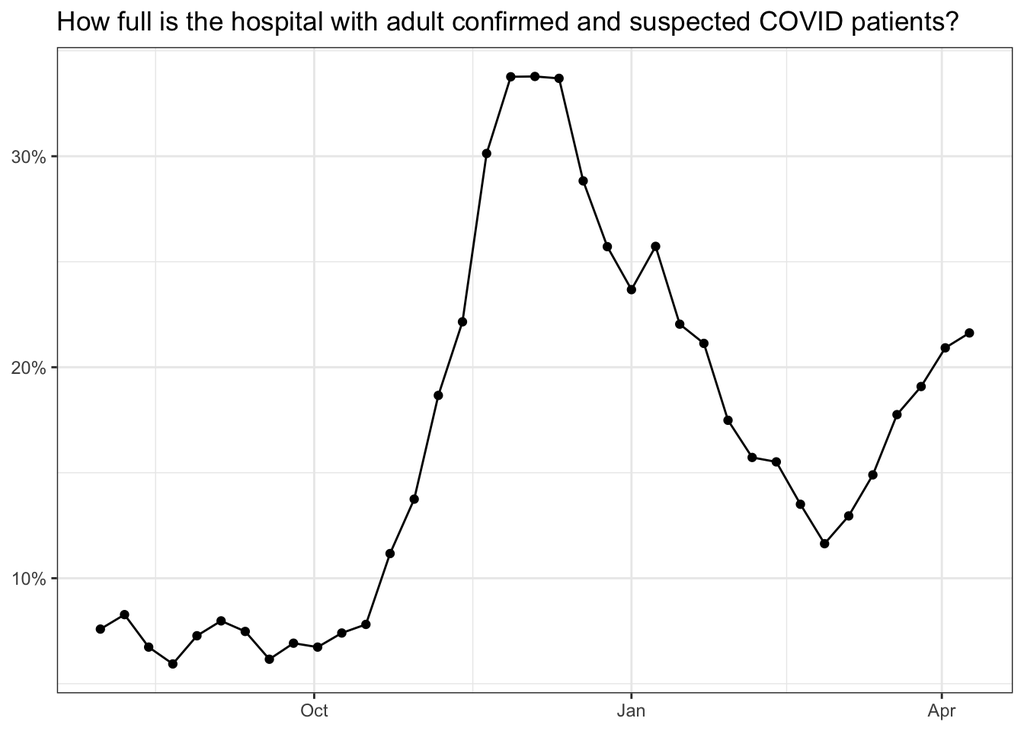

```r
theme_set(theme_bw())

hospital_metrics %>%
  select(collection_week, hospital_name, is_metro_micro:last_col()) %>%
  filter(hospital_name == "TEMPLE UNIVERSITY HOSPITAL") %>%
  ggplot(aes(x = collection_week, y = beds_covid_occupied)) +
  geom_point() +
  geom_line() +
  scale_y_continuous(labels = scales::label_percent()) +
  labs(title = "How full is the hospital with adult confirmed and suspected COVID patients?", x = NULL, y = NULL)
```

# Historial Information

### New admissions

```r
# Timeseries for state
state_utilization_timeseries <- vroom("https://healthdata.gov/api/views/g62h-syeh/rows.csv?accessType=DOWNLOAD")

pcr_testing_timeseries <- covid_datasets$pcr_testing_timeseries

cases_and_death_state_timeseries <- covid_datasets$cases_and_deaths_state_timeseries
```

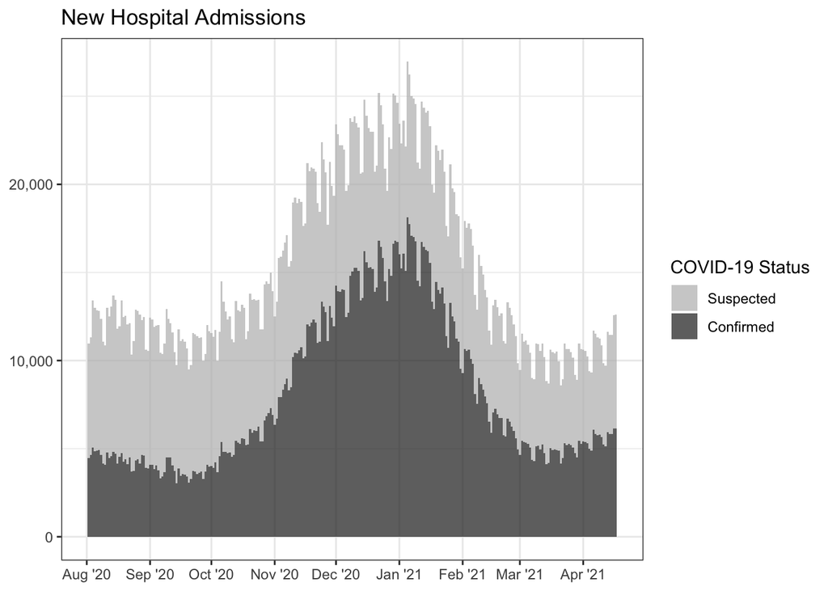

```r
theme_set(theme_bw())
state_utilization_timeseries %>%
  filter(date > lubridate::mdy("Aug 01 2020")) %>%
  select(state, date,
         previous_day_admission_adult_covid_confirmed,
         previous_day_admission_pediatric_covid_confirmed,
         previous_day_admission_adult_covid_suspected,
         previous_day_admission_pediatric_covid_suspected) %>%
  group_by(date) %>%
  summarize(confirmed = sum(previous_day_admission_adult_covid_confirmed, previous_day_admission_pediatric_covid_confirmed, na.rm = TRUE),
            suspected = sum(previous_day_admission_adult_covid_suspected, previous_day_admission_pediatric_covid_suspected, na.rm = TRUE)) %>%
  pivot_longer(c(confirmed, suspected), names_to = "type", values_to = "cases") %>%
  mutate(type = str_to_title(type),
         type = fct_relevel(type, c("Suspected", "Confirmed"))) %>%
  ggplot(aes(x = date, y = cases, fill = type)) +
  geom_col(width = 1, alpha = 0.75) +
  scale_x_date(date_breaks = "month", minor_breaks = NULL,
               date_labels = "%b '%y") +
  scale_y_continuous(labels = scales::comma) +
  scale_fill_manual(values = c("gray75", "gray20")) +
  expand_limits(y = 0) +
  labs(title = "New Hospital Admissions",
       y = NULL, x = NULL, fill = "COVID-19 Status")
```

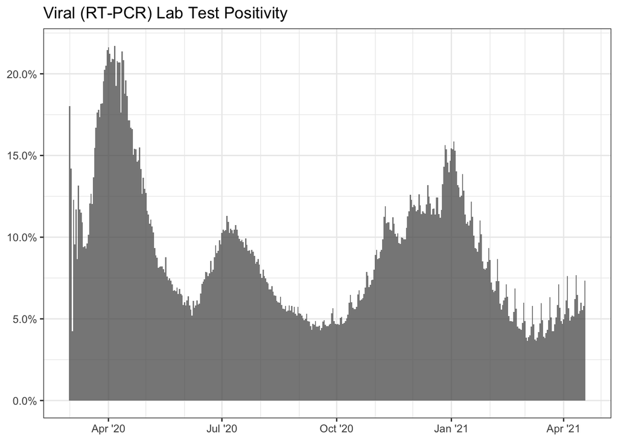

```r
pcr_testing_timeseries %>%
  group_by(date, overall_outcome) %>%
  summarize(new_results_reported = sum(new_results_reported)) %>%
  arrange(desc(date), overall_outcome) %>%
  add_tally(new_results_reported) %>%
  filter(overall_outcome == "Positive") %>%
  mutate(test_positivity = new_results_reported/n) %>%
  ggplot(aes(x = date, y = test_positivity)) +
  geom_col(width = 1, alpha = 0.75) +
  scale_x_date(minor_breaks = "month", date_labels = "%b '%y") +
  scale_y_continuous(labels = scales::percent) +
  labs(x = NULL, y = NULL, title = "Viral (RT-PCR) Lab Test Positivity")
```

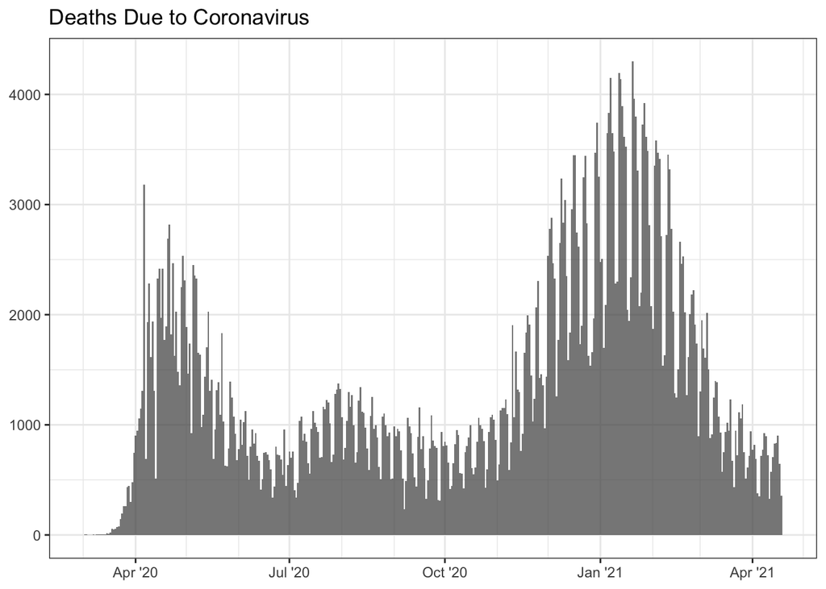

```r
cases_and_death_state_timeseries %>%
  mutate(submission_date = lubridate::mdy(submission_date)) %>%
  filter(submission_date > lubridate::mdy("Mar 1 2020")) %>%
  select(1:2, new_death) %>%
  arrange(desc(submission_date), state, new_death) %>%
  count(submission_date, wt = new_death) %>%
  arrange(submission_date) %>%
  ggplot(aes(x = submission_date, y = n)) +
  geom_col(width = 1, alpha = 0.75) +
  scale_x_date(minor_breaks = "month", date_labels = "%b '%y") +
  labs(x = NULL, y = NULL, title = "Deaths Due to Coronavirus")
```

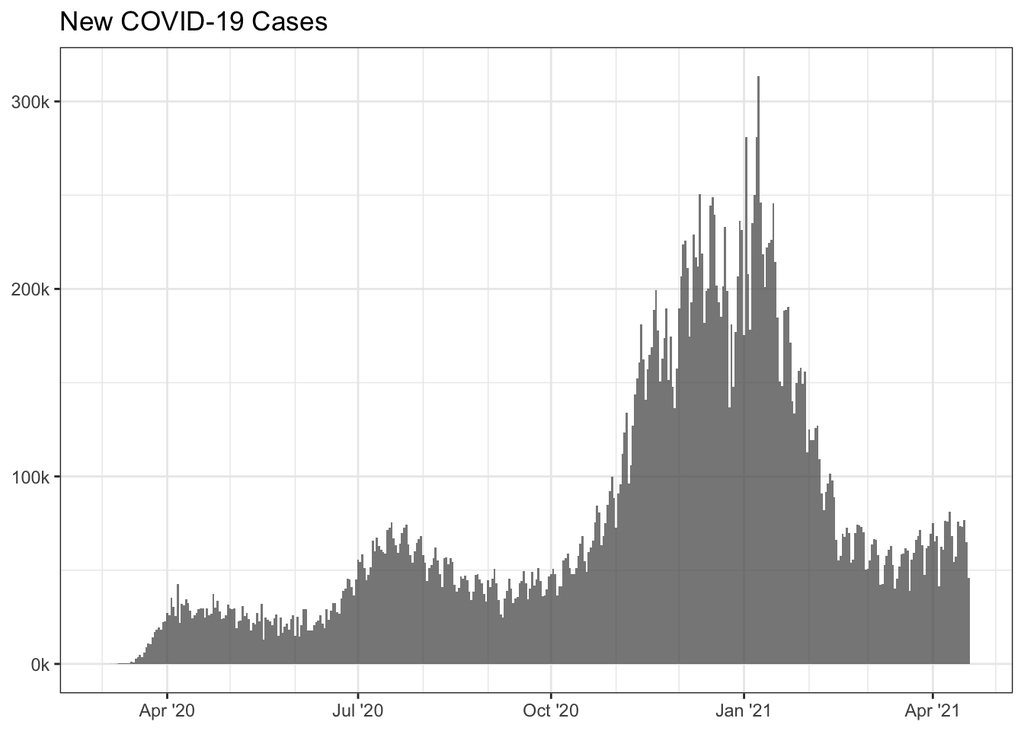

```r
cases_and_death_state_timeseries %>%
  mutate(submission_date = lubridate::mdy(submission_date)) %>%
  filter(submission_date > lubridate::mdy("Mar 1 2020")) %>%
  select(1:2, new_case) %>%
  arrange(desc(submission_date), state, new_case) %>%
  # filter(submission_date == min(submission_date)) %>%
  count(submission_date, wt = new_case) %>%
  arrange(submission_date) %>%
  ggplot(aes(x = submission_date, y = n)) +
  geom_col(width = 1, alpha = 0.75) +
  scale_x_date(minor_breaks = "month", date_labels = "%b '%y") +
  scale_y_continuous(labels = scales::label_number(scale = 1/1e3, suffix = "k")) +
  labs(x = NULL, y = NULL, title = "New COVID-19 Cases")
```

# Vaccination information

TODO